# Module 6: GARCH Models

STAT 4170 – Financial Time Series and Forecasting

Taylor R. Brown

# Part 1: Motivation — Volatility Clustering

## The Limitation of ARMA

ARMA models assume the noise variance $\sigma^2$ is **constant** regardless of time.

This is clearly violated in financial returns. Consider daily volatility across financial markets broadly:

- **2006:** annual volatility $\approx 10\%$
- **2008:** annual volatility $\approx 40\%$
- **2020 (March):** daily moves of 5–10%

No ARMA model captures this. We need a model where the conditional variance evolves over time.

## Volatility Clustering in FX Returns

Our running example — the AUD/JPY carry trade — shows the same pattern. Large moves cluster in time:

```python
import numpy as np
import pandas as pd
import matplotlib.pyplot as plt

carry = pd.read_csv("../data/carry_pnl.csv", index_col=0, parse_dates=True)["carry_pnl"]

fig, ax = plt.subplots(figsize=(10, 4))
carry.plot(ax=ax, lw=0.6, color="steelblue")
ax.set_title("AUD/JPY Carry P&L (%)")
ax.set_xlabel("Date")
ax.set_ylabel("Carry P&L (%)")
plt.tight_layout()
plt.show()
```

Notice the calm stretches punctuated by bursts of large moves — the visual signature of volatility clustering, and exactly what GARCH is built to model.

## Volatility Clustering in FX Returns

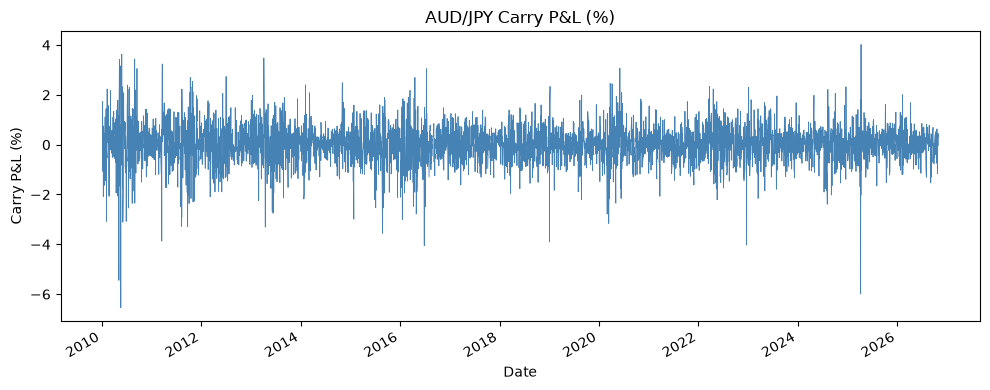

## Stylized Facts of Financial Returns

| Stylized Fact | Description |
| --- | --- |
| **Volatility clustering** | Large moves tend to follow large moves; calm periods follow calm periods |
| **Heavy tails** | More extreme observations than Normal predicts |
| **Asymmetry** | Negative returns often trigger larger volatility increases than positive returns of the same magnitude |
| **Uncorrelated but dependent** | Returns $Z_t$ are uncorrelated, but $Z_t^2$ is autocorrelated |

ARMA handles correlation in $Z_t$. GARCH handles dependence in $Z_t^2$.

## Heavy Tails: A QQ-Plot

If AUD/JPY returns were Normal, the points below would fall on the red line. They don’t — the tails are fatter than Normal predicts:

```python
import numpy as np
import pandas as pd
import scipy.stats as stats
import matplotlib.pyplot as plt

carry = pd.read_csv("../data/carry_pnl.csv", index_col=0, parse_dates=True)["carry_pnl"]

fig, ax = plt.subplots(figsize=(6, 6))
stats.probplot(carry, dist="norm", plot=ax)
ax.set_title("QQ-Plot: AUD/JPY Carry P&L vs. Normal")
plt.tight_layout()
plt.show()
```

The S-shaped departure from the line at both ends is the signature of heavy tails: extreme moves happen far more often than a Normal distribution would suggest.

## Heavy Tails: A QQ-Plot

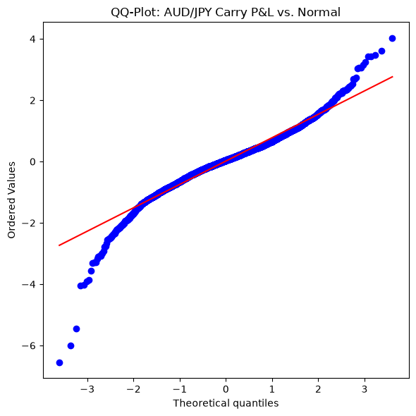

## Asymmetry: The Leverage Effect

Does a large *negative* return today predict more volatility tomorrow than a large *positive* return of the same size? Plot today’s return against tomorrow’s squared return:

```python
import numpy as np
import pandas as pd
import matplotlib.pyplot as plt

carry = pd.read_csv("../data/carry_pnl.csv", index_col=0, parse_dates=True)["carry_pnl"]

today = carry.iloc[:-1].to_numpy()
tomorrow_sq = (carry.iloc[1:] ** 2).to_numpy()
corr = np.corrcoef(today, tomorrow_sq)[0, 1]

fig, ax = plt.subplots(figsize=(7, 5))
ax.scatter(today, tomorrow_sq, s=8, alpha=0.4, color="steelblue")
ax.axvline(0, color="black", lw=0.8)
ax.text(0.03, 0.95, f"corr = {corr:.3f}", transform=ax.transAxes,
        va="top", fontsize=12,
        bbox=dict(boxstyle="round", facecolor="white", alpha=0.8))
ax.set_yscale("log")
ax.set_xlabel(r"Return today, $Z_t$ (%)")
ax.set_ylabel(r"Squared return tomorrow, $Z_{t+1}^2$ (log scale)")
ax.set_title("Leverage Effect: AUD/JPY Carry P&L")
plt.tight_layout()
plt.show()
```

In equities this scatter is usually lopsided — the left half (negative returns) sits higher than the right half, an asymmetry GARCH extensions like GJR-GARCH and EGARCH are designed to capture. For our FX carry pair, the effect is typically weaker or absent — check the plot above to see whether that holds here.

## Asymmetry: The Leverage Effect

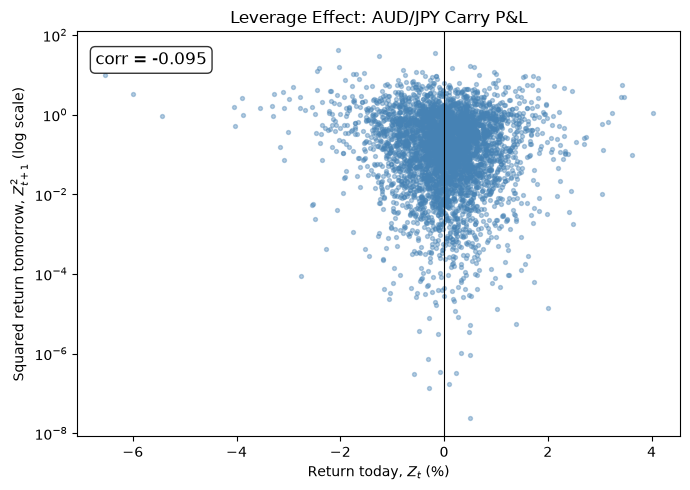

## Conditional vs. Unconditional Variance

**Unconditional variance:** $\text{Var}(Z_t) = E[Z_t^2]$ — the long-run average level of volatility.

**Conditional variance:**
$$h_t = \text{Var}(Z_t \mid Z_{1:t-1}) = E[Z_t^2 \mid Z_{1:t-1}]$$

$h_t$ varies day by day. After a volatile Friday, Monday’s $h_t$ should be elevated.

GARCH models $h_t$ as a function of past data. A fitted model can provide a **one-step-ahead volatility forecast** $\hat{h}_{t+1|t}$.

# Part 2: ARCH and GARCH Models

## The General Pattern: Time-Varying Volatility

Every model in this section shares the same skeleton:

$$Z_t = \sqrt{h_t}\, e_t, \quad \{e_t\} \overset{\text{iid}}{\sim} (0, 1)$$

- $h_t$ is a positive scalar — the **conditional variance** at time $t$ — controlling how spread out $Z_t$ is around zero.
- $e_t$ is unpredictable, unit-variance noise; it carries no memory of the past on its own.
- All of the time-dependence lives in $h_t$. ARCH, GARCH, and their variants are really just different ways of modeling *how $h_t$ evolves* from the past.

## ARCH(p): Definition

**AutoRegressive Conditional Heteroscedasticity** (Engle, 1982):

$$Z_t = \sqrt{h_t}\, e_t, \quad \{e_t\} \sim \text{IID}(0, 1)$$
$$h_t = \alpha_0 + \alpha_1 Z_{t-1}^2 + \cdots + \alpha_p Z_{t-p}^2$$

**Constraints:** $\alpha_0 > 0$, $\alpha_i \geq 0$ for $i=1,\ldots,p$.

**Interpretation:**

- Large past squared returns $\Rightarrow$ large $h_t$ $\Rightarrow$ large expected absolute future moves.
- Setting all $\alpha_i = 0$ gives constant variance = white noise.

## GARCH(p, q): Definition

**Generalized ARCH** (Bollerslev, 1986):

$$Z_t = \sqrt{h_t}\, e_t, \quad \{e_t\} \sim \text{IID}(0, 1)$$
$$h_t = \alpha_0 + \sum_{i=1}^p \alpha_i Z_{t-i}^2 + \sum_{j=1}^q \beta_j h_{t-j}$$

**Constraints:** $\alpha_0 > 0$, $\alpha_i \geq 0$, $\beta_j \geq 0$.

Adding lagged $h_{t-j}$ terms is like giving the variance an AR structure. GARCH(1,1) is far more parsimonious than ARCH(10) but fits almost as well in practice.

## GARCH(1,1): The Workhorse

Maybe the most widely used specification in practice:

$$h_t = \alpha_0 + \alpha_1 Z_{t-1}^2 + \beta_1 h_{t-1}$$

**Stationarity condition:** $\alpha_1 + \beta_1 < 1$.

**Unconditional variance:**
$$E[Z_t^2] = \frac{\alpha_0}{1 - \alpha_1 - \beta_1}$$

**Typical fitted values:** $\alpha_1 \approx 0.05$–$0.15$, $\beta_1 \approx 0.80$–$0.90$.

The **persistence** $\alpha_1 + \beta_1$ near 1 means volatility shocks die out slowly.

## GARCH Is White Noise, Not IID

The $\{Z_t\}$ process in GARCH is **white noise**: $\text{Cov}(Z_{t+h}, Z_t) = 0$ for $h \neq 0$.

Proof sketch:

$$\begin{align*}
E[Z_{t+h} Z_t] &= E\!\left[E(Z_{t+h} Z_t \mid Z_{1:t+h-1})\right] \\
&= E\!\left[Z_t \cdot E(Z_{t+h} \mid Z_{1:t+h-1})\right] \\
&= E[Z_t \cdot 0] = 0
\end{align*}$$

But the squared process $\{Z_t^2\}$ **is** autocorrelated:

$$\text{Cov}(Z_t^2, Z_{t-1}^2) = \alpha_1 \cdot \text{Var}(Z_t^2) > 0$$

This is why we look at the ACF of squared returns to detect GARCH effects.

## ACF of Squared Returns: AUD/JPY

The raw returns show little autocorrelation, but their squares do — evidence of GARCH-type dependence:

```python
import numpy as np
import pandas as pd
from statsmodels.graphics.tsaplots import plot_acf
import matplotlib.pyplot as plt

carry = pd.read_csv("../data/carry_pnl.csv", index_col=0, parse_dates=True)["carry_pnl"]

fig, axes = plt.subplots(1, 2, figsize=(12, 4))
plot_acf(carry, lags=20, ax=axes[0], title="ACF: AUD/JPY Carry P&L")
plot_acf(carry**2, lags=20, ax=axes[1], title="ACF: AUD/JPY Squared Carry P&L")
plt.tight_layout()
plt.show()
```

Returns themselves are close to white noise, but the squared returns show clear, slowly decaying autocorrelation — the hallmark of volatility clustering that GARCH is built to capture.

## ACF of Squared Returns: AUD/JPY

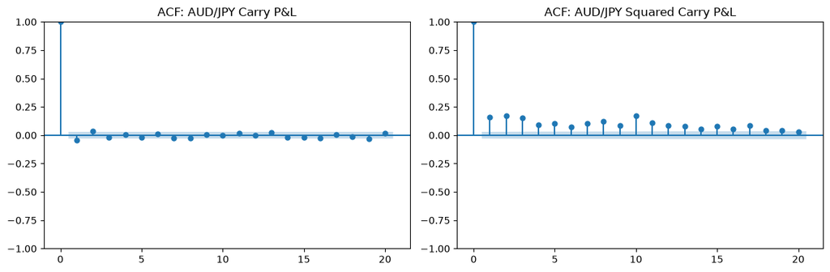

## ARCH(1): Stationarity

For ARCH(1), repeated substitution shows (when $\alpha_1 < 1$):

$$Z_t^2 = \alpha_0 \sum_{j=0}^\infty \alpha_1^j \, e_t^2 e_{t-1}^2 \cdots e_{t-j}^2$$

From this representation:

$$E[Z_t] = 0, \quad \text{Var}(Z_t) = \frac{\alpha_0}{1 - \alpha_1}, \quad \text{Cov}(Z_{t+h}, Z_t) = 0$$

So ARCH(1) is **weakly stationary** (white noise) when $\alpha_1 < 1$, but not IID.

## ARCH(1) Doesn’t Capture Long-Range Dependence

The ARCH(1) formula above shows $\text{Cov}(Z_t^2, Z_{t-h}^2) \propto \alpha_1^h$ — a **geometric** decay that dies out fast. Adding a GARCH term lets that decay persist much longer:

```python
import numpy as np
import pandas as pd
from statsmodels.graphics.tsaplots import plot_acf
import matplotlib.pyplot as plt

rng = np.random.default_rng(0)
n = 5000

# Simulated ARCH(1)
alpha0, alpha1 = 0.1, 0.3
e = rng.standard_normal(n)
z = np.zeros(n)
h = np.zeros(n)
h[0] = alpha0 / (1 - alpha1)
z[0] = np.sqrt(h[0]) * e[0]
for t in range(1, n):
    h[t] = alpha0 + alpha1 * z[t - 1] ** 2
    z[t] = np.sqrt(h[t]) * e[t]
sim_arch = pd.Series(z)

# Simulated GARCH(1,1) — same unconditional variance, high persistence
g_alpha0, g_alpha1, g_beta1 = 0.00714, 0.1, 0.85
e2 = rng.standard_normal(n)
z2 = np.zeros(n)
h2 = np.zeros(n)
h2[0] = g_alpha0 / (1 - g_alpha1 - g_beta1)
z2[0] = np.sqrt(h2[0]) * e2[0]
for t in range(1, n):
    h2[t] = g_alpha0 + g_alpha1 * z2[t - 1] ** 2 + g_beta1 * h2[t - 1]
    z2[t] = np.sqrt(h2[t]) * e2[t]
sim_garch = pd.Series(z2)

carry = pd.read_csv("../data/carry_pnl.csv", index_col=0, parse_dates=True)["carry_pnl"]

fig, axes = plt.subplots(1, 3, figsize=(15, 4))
plot_acf(sim_arch**2, lags=20, ax=axes[0], title="Simulated ARCH(1): Squared Returns")
plot_acf(sim_garch**2, lags=20, ax=axes[1], title="Simulated GARCH(1,1): Squared Returns")
plot_acf(carry**2, lags=20, ax=axes[2], title="AUD/JPY: Squared Carry P&L")
plt.tight_layout()
plt.show()
```

The ARCH(1) and GARCH(1,1) series have the same unconditional variance, but the ARCH(1) autocorrelations vanish after a few lags while the GARCH(1,1) autocorrelations — driven by persistence $\alpha_1 + \beta_1 = 0.95$ — decay much more slowly. The real AUD/JPY squared returns show the same slowly-decaying pattern as the simulated GARCH(1,1), not the fast-decaying ARCH(1) — evidence that GARCH is the better-fitting model.

## ARCH(1) Doesn’t Capture Long-Range Dependence

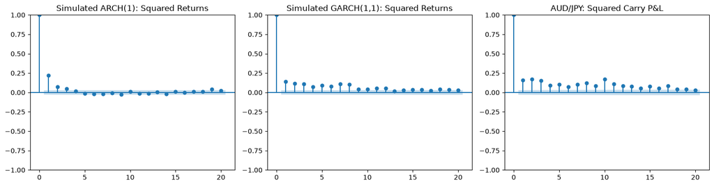

## Stochastic Volatility (for context)

An alternative that separates the latent volatility from the observations:

$$Z_t = \sqrt{h_t}\, e_t, \quad \{e_t\} \sim \text{IID}(0, 1)$$
$$\log h_t = \gamma_0 + \gamma_1 \log h_{t-1} + \eta_t, \quad \{\eta_t\} \sim \text{IID}(0, \tau^2)$$

Log-volatility follows an AR(1) driven by independent noise $\eta_t$.

**Pros:** More flexible, natural latent-variable interpretation.

**Cons:** The likelihood is intractable — requires particle filters or MCMC.

We focus on GARCH because it has a closed-form likelihood. The straightforward MLE explains why these are way more popular in practice.

# Part 3: Fitting GARCH in Python

## The `arch` Package

```python
from arch import arch_model
import numpy as np
import pandas as pd

carry = pd.read_csv("../data/carry_pnl.csv", index_col=0, parse_dates=True)["carry_pnl"]

am = arch_model(carry, vol="Garch", p=1, q=1, dist="Normal")
res = am.fit(disp="off")
print(res.summary())
```

## The `arch` Package

```
                     Constant Mean - GARCH Model Results
==============================================================================
Dep. Variable:              carry_pnl   R-squared:                       0.000
Mean Model:             Constant Mean   Adj. R-squared:                  0.000
Vol Model:                      GARCH   Log-Likelihood:               -4756.83
Distribution:                  Normal   AIC:                           9521.66
Method:            Maximum Likelihood   BIC:                           9547.20
                                        No. Observations:                 4381
Date:                Thu, Oct 29 2026   Df Residuals:                     4380
Time:                        18:49:43   Df Model:                            1
                                 Mean Model
============================================================================
                 coef    std err          t      P>|t|      95.0% Conf. Int.
----------------------------------------------------------------------------
mu             0.0258  9.773e-03      2.636  8.398e-03 [6.603e-03,4.491e-02]
                              Volatility Model
============================================================================
                 coef    std err          t      P>|t|      95.0% Conf. Int.
----------------------------------------------------------------------------
omega          0.0222  6.898e-03      3.225  1.259e-03 [8.727e-03,3.577e-02]
alpha[1]       0.1107  2.220e-02      4.988  6.095e-07   [6.722e-02,  0.154]
beta[1]        0.8549  2.925e-02     29.228 8.473e-188     [  0.798,  0.912]
============================================================================

Covariance estimator: robust
```

## Interpreting the Output

Key parameters from the GARCH(1,1) fit:

[output not shown]

A significant `alpha[1]` confirms volatility clustering. Persistence $\alpha_1 + \beta_1$ close to 1 means shocks die out slowly.

## Plotting Conditional Volatility

```python
from arch import arch_model
import numpy as np
import pandas as pd
import matplotlib.pyplot as plt

carry = pd.read_csv("../data/carry_pnl.csv", index_col=0, parse_dates=True)["carry_pnl"]

am = arch_model(carry, vol="Garch", p=1, q=1, dist="Normal")
res = am.fit(disp="off")

fig, axes = plt.subplots(2, 1, figsize=(10, 6), sharex=True)
carry.plot(ax=axes[0], title="AUD/JPY Carry P&L (%)", alpha=0.7)
np.sqrt(res.conditional_volatility).plot(
    ax=axes[1], title="Conditional Volatility (%)", color="red"
)
plt.tight_layout()
plt.show()
```

## Plotting Conditional Volatility

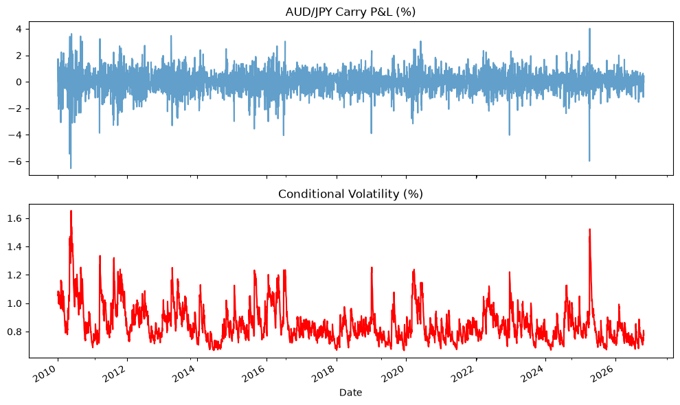

## Residual Diagnostics

After fitting GARCH, examine the **standardized residuals**:

$$\hat{e}_t = \frac{Z_t}{\sqrt{\hat{h}_t}}$$

These should behave like IID noise if the model is correctly specified.

```python
from statsmodels.stats.diagnostic import acorr_ljungbox

std_resid = res.std_resid
lb = acorr_ljungbox(std_resid**2, lags=[5, 10, 20], return_df=True)
print(lb)
```

```
      lb_stat  lb_pvalue
5    3.097918   0.684893
10   9.361687   0.498156
20  18.103152   0.580613
```

If squared standardized residuals still show autocorrelation, try a higher-order GARCH or a different error distribution.

## Student-$t$ Innovations

Financial returns have heavier tails than Normal. Fit GARCH with Student-$t$ innovations:

```python
from arch import arch_model
import numpy as np
import pandas as pd

carry = pd.read_csv("../data/carry_pnl.csv", index_col=0, parse_dates=True)["carry_pnl"]

am_t = arch_model(carry, vol="Garch", p=1, q=1, dist="t") # boop!
res_t = am_t.fit(disp="off")
print(res_t.summary())
```

Compare AIC/BIC between the Normal and $t$ specifications. The $t$ typically wins for financial returns.

## Student-$t$ Innovations

```
                        Constant Mean - GARCH Model Results
====================================================================================
Dep. Variable:                    carry_pnl   R-squared:                       0.000
Mean Model:                   Constant Mean   Adj. R-squared:                  0.000
Vol Model:                            GARCH   Log-Likelihood:               -4645.72
Distribution:      Standardized Student's t   AIC:                           9301.45
Method:                  Maximum Likelihood   BIC:                           9333.37
                                              No. Observations:                 4381
Date:                      Thu, Oct 29 2026   Df Residuals:                     4380
Time:                              18:49:43   Df Model:                            1
                                 Mean Model
============================================================================
                 coef    std err          t      P>|t|      95.0% Conf. Int.
----------------------------------------------------------------------------
mu             0.0350  9.222e-03      3.791  1.502e-04 [1.688e-02,5.303e-02]
                              Volatility Model
============================================================================
                 coef    std err          t      P>|t|      95.0% Conf. Int.
----------------------------------------------------------------------------
omega          0.0209  6.580e-03      3.179  1.479e-03 [8.020e-03,3.381e-02]
alpha[1]       0.1073  1.972e-02      5.439  5.352e-08   [6.862e-02,  0.146]
beta[1]        0.8602  2.750e-02     31.278 9.392e-215     [  0.806,  0.914]
                              Distribution
========================================================================
                 coef    std err          t      P>|t|  95.0% Conf. Int.
------------------------------------------------------------------------
nu             6.4912      0.626     10.377  3.139e-25 [  5.265,  7.717]
========================================================================

Covariance estimator: robust
```

# Part 4: CS 2 — Strategy Evaluation

## Volatility-Scaled Positions

The GARCH(1,1) one-step-ahead volatility forecast:

$$\hat{h}_{t+1|t} = \hat{\alpha}_0 + \hat{\alpha}_1 Z_t^2 + \hat{\beta}_1 \hat{h}_t$$

**Volatility targeting:** scale position size inversely with forecast volatility to maintain constant risk:

$$w_t = \frac{\sigma^*}{\hat{\sigma}_{t+1|t}}, \quad \hat{\sigma}_{t+1|t} = \sqrt{\hat{h}_{t+1|t}}$$

where $\sigma^*$ is the desired (target) daily volatility. The scaled return is $w_t \cdot Z_{t+1}$.

## Implementing Volatility Targeting

Beware the leakage…

```python
from arch import arch_model
import numpy as np
import pandas as pd
import matplotlib.pyplot as plt

carry = pd.read_csv("../data/carry_pnl.csv", index_col=0, parse_dates=True)["carry_pnl"]

am = arch_model(carry, vol="Garch", p=1, q=1, dist="t")
res = am.fit(disp="off")

target_vol = carry.std()
weights = target_vol / res.conditional_volatility
scaled = (weights.shift(1) * carry).dropna()

fig, axes = plt.subplots(2, 1, figsize=(10, 6))
carry.cumsum().plot(ax=axes[0], label="Unscaled")
scaled.cumsum().plot(ax=axes[0], label="Vol-Scaled")
axes[0].set_title("Cumulative Return (%)")
axes[0].legend()
weights.plot(ax=axes[1], title="Position Multiplier")
plt.tight_layout()
plt.show()
```

## Implementing Volatility Targeting

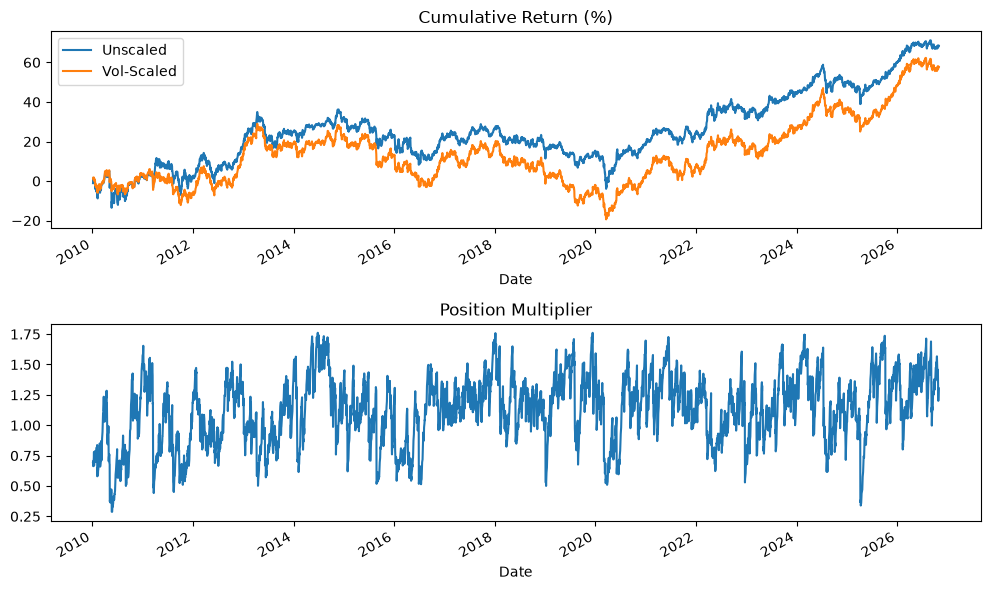

## Performance Metrics

```python
import numpy as np
import pandas as pd

def annualized_sharpe(rets, freq=252):
    return rets.mean() / rets.std() * np.sqrt(freq)

def max_drawdown(rets):
    cum = rets.cumsum()
    return (cum - cum.cummax()).min()

raw = carry.dropna()
vol_scaled = scaled.dropna()

stats = pd.DataFrame({
    "Unscaled": {
        "Ann. Return (%)": raw.mean() * 252,
        "Ann. Vol (%)": raw.std() * 252**0.5,
        "Sharpe": annualized_sharpe(raw),
        "Max Drawdown (%)": max_drawdown(raw),
    },
    "Vol-Scaled": {
        "Ann. Return (%)": vol_scaled.mean() * 252,
        "Ann. Vol (%)": vol_scaled.std() * 252**0.5,
        "Sharpe": annualized_sharpe(vol_scaled),
        "Max Drawdown (%)": max_drawdown(vol_scaled),
    },
}).round(2)

print(stats)
```

## Performance Metrics

```
                  Unscaled  Vol-Scaled
Ann. Return (%)       3.94        3.33
Ann. Vol (%)         12.37       12.49
Sharpe                0.32        0.27
Max Drawdown (%)    -40.08      -48.32
```

## Value at Risk from GARCH

GARCH also gives us a better VaR estimate than using the unconditional distribution.

**Conditional VaR** at confidence level $\alpha$:

$$\text{VaR}_\alpha^{(t+1)} = -\hat{\sigma}_{t+1|t} \cdot q_\alpha$$

where $q_\alpha$ is the $\alpha$-quantile of the fitted innovation distribution (e.g., $t_\nu$).

```python
from scipy.stats import t as student_t
import numpy as np
import pandas as pd

# extract GARCH params (from t-innovation fit)
nu = res_t.params["nu"]  # degrees of freedom
sigma_forecast = np.sqrt(res_t.conditional_volatility.iloc[-1])  # last fitted vol

alpha = 0.05
q_alpha = student_t.ppf(alpha, df=nu)
VaR_pct = -sigma_forecast * q_alpha
P = 1_000_000  # $1M position

print(f"1-day conditional vol:  {sigma_forecast:.4f}%")
print(f"5% conditional VaR:     {VaR_pct:.4f}%  (${P * VaR_pct / 100:,.0f})")
```

## Value at Risk from GARCH

```
1-day conditional vol:  0.7732%
5% conditional VaR:     1.4823%  ($14,823)
```

## What We Learned: Part 2 Summary

Over Modules 3–6, we built a complete univariate pipeline for the FX carry trade:

| Module | Tool | Key Finding |
| --- | --- | --- |
| 3 | Stationarity, ACVF | FX log returns are approximately stationary; FX levels are not |
| 4 | IID noise, random walks, sample ACF | Log prices behave like random walks; returns look like white noise in the mean |
| 5 | AR/MA/ARMA | Returns have minimal mean predictability (near-efficient market) |
| 6 | GARCH | Volatility clustering; probably refitting this model less frequently and trusting it more than ARMA |

## Limitations of This Strategy/Code

- **One pair only:** using AUD/JPY ignores the broader G10 carry basket.
- **Simple interest accrual:** we approximate the daily carry as the annualized rate differential divided by 365, ignoring compounding and day-count conventions a live desk would use.
- **Regime changes:** carry can be stable for years and then crash suddenly (e.g., 2008 “carry unwind”).
- **Transaction costs:** bid-ask spreads in FX are small but nonzero, especially during stress.
- **Look-ahead bias:** in-sample GARCH fit uses future information in conditional volatility calculation.

A production carry strategy would address all of these — but the analytical tools are exactly what we built here.

## Looking Ahead: Part 3

The next section moves from **discrete time** to **continuous time**:

- Poisson processes and Brownian motion, motivated by high-frequency market making (Module 7)
- U.S. equity market structure — the institutional plumbing behind real order flow (Module 8)
- Martingales and Itô’s lemma (Module 9)
- The Black-Scholes derivation (Module 10)
- Black-Scholes implementation, the Greeks, and hedging (Module 11)

The carry trade and portfolio construction used return series at daily (or lower) frequency. The case studies ahead — market making (CS 3) and options (CS 4) — require modeling prices continuously, a fundamentally different framework.

## References

- Engle, R. F. (1982). *Autoregressive Conditional Heteroscedasticity with Estimates of the Variance of United Kingdom Inflation*. Econometrica, 50(4), 987–1007.
- Bollerslev, T. (1986). *Generalized Autoregressive Conditional Heteroscedasticity*. Journal of Econometrics, 31(3), 307–327.
- Brockwell, P. J. & Davis, R. A. (2016). *Introduction to Time Series and Forecasting* (3rd ed.). Springer.